# Akanksha_Dhall_NeuralNetwork

```python
from google.colab import drive
drive.mount('/content/drive')
```

**PART-A**

**1.A Read the ‘Signals.csv’ as DataFrame and import required libraries**

```python
import pandas as pd
import numpy as np
import seaborn as sns
import matplotlib.pyplot as plt
%matplotlib inline
from sklearn.model_selection import train_test_split
import warnings
warnings.filterwarnings('ignore')
from scipy.stats import zscore
from collections import Counter
```

```python
df_signal = pd.read_csv('/content/drive/MyDrive/Colab Notebooks/NNProjectDataSignal.csv')
df_signal.head()
```

|  | Parameter 1 | Parameter 2 | Parameter 3 | Parameter 4 | Parameter 5 | Parameter 6 | Parameter 7 | Parameter 8 | Parameter 9 | Parameter 10 | Parameter 11 | Signal_Strength |
| --- | --- | --- | --- | --- | --- | --- | --- | --- | --- | --- | --- | --- |
| 0 | 7.4 | 0.70 | 0.00 | 1.9 | 0.076 | 11.0 | 34.0 | 0.9978 | 3.51 | 0.56 | 9.4 | 5 |
| 1 | 7.8 | 0.88 | 0.00 | 2.6 | 0.098 | 25.0 | 67.0 | 0.9968 | 3.20 | 0.68 | 9.8 | 5 |
| 2 | 7.8 | 0.76 | 0.04 | 2.3 | 0.092 | 15.0 | 54.0 | 0.9970 | 3.26 | 0.65 | 9.8 | 5 |
| 3 | 11.2 | 0.28 | 0.56 | 1.9 | 0.075 | 17.0 | 60.0 | 0.9980 | 3.16 | 0.58 | 9.8 | 6 |
| 4 | 7.4 | 0.70 | 0.00 | 1.9 | 0.076 | 11.0 | 34.0 | 0.9978 | 3.51 | 0.56 | 9.4 | 5 |

```python
df_signal.shape
```

```
(1599, 12)
```

```python
df_signal.info()
```

```
<class 'pandas.core.frame.DataFrame'>
RangeIndex: 1599 entries, 0 to 1598
Data columns (total 12 columns):
 #   Column           Non-Null Count  Dtype
---  ------           --------------  -----
 0   Parameter 1      1599 non-null   float64
 1   Parameter 2      1599 non-null   float64
 2   Parameter 3      1599 non-null   float64
 3   Parameter 4      1599 non-null   float64
 4   Parameter 5      1599 non-null   float64
 5   Parameter 6      1599 non-null   float64
 6   Parameter 7      1599 non-null   float64
 7   Parameter 8      1599 non-null   float64
 8   Parameter 9      1599 non-null   float64
 9   Parameter 10     1599 non-null   float64
 10  Parameter 11     1599 non-null   float64
 11  Signal_Strength  1599 non-null   int64
dtypes: float64(11), int64(1)
memory usage: 150.0 KB
```

**1.B Check for missing values and print percentage for each attribute**

```python
df_signal.isna().sum()
```

```
Parameter 1        0
Parameter 2        0
Parameter 3        0
Parameter 4        0
Parameter 5        0
Parameter 6        0
Parameter 7        0
Parameter 8        0
Parameter 9        0
Parameter 10       0
Parameter 11       0
Signal_Strength    0
dtype: int64
```

There is no null value in the dataset.

```python
round(df_signal.isnull().sum() / df_signal.isnull().count() * 100, 2)
```

```
Parameter 1        0.0
Parameter 2        0.0
Parameter 3        0.0
Parameter 4        0.0
Parameter 5        0.0
Parameter 6        0.0
Parameter 7        0.0
Parameter 8        0.0
Parameter 9        0.0
Parameter 10       0.0
Parameter 11       0.0
Signal_Strength    0.0
dtype: float64
```

**1.C. Check for presence of duplicate records in the dataset and impute with appropriate method.**

```python
df_signal.duplicated().sum()
```

```
240
```

There are 240 rows duplicated. So dropping the duplicate data.

```python
df_signal = df_signal.drop_duplicates()
df_signal.head()
```

|  | Parameter 1 | Parameter 2 | Parameter 3 | Parameter 4 | Parameter 5 | Parameter 6 | Parameter 7 | Parameter 8 | Parameter 9 | Parameter 10 | Parameter 11 | Signal_Strength |
| --- | --- | --- | --- | --- | --- | --- | --- | --- | --- | --- | --- | --- |
| 0 | 7.4 | 0.70 | 0.00 | 1.9 | 0.076 | 11.0 | 34.0 | 0.9978 | 3.51 | 0.56 | 9.4 | 5 |
| 1 | 7.8 | 0.88 | 0.00 | 2.6 | 0.098 | 25.0 | 67.0 | 0.9968 | 3.20 | 0.68 | 9.8 | 5 |
| 2 | 7.8 | 0.76 | 0.04 | 2.3 | 0.092 | 15.0 | 54.0 | 0.9970 | 3.26 | 0.65 | 9.8 | 5 |
| 3 | 11.2 | 0.28 | 0.56 | 1.9 | 0.075 | 17.0 | 60.0 | 0.9980 | 3.16 | 0.58 | 9.8 | 6 |
| 5 | 7.4 | 0.66 | 0.00 | 1.8 | 0.075 | 13.0 | 40.0 | 0.9978 | 3.51 | 0.56 | 9.4 | 5 |

**1.4 Visualise distribution of the target variable**

```python
signal_distribution=df_signal['Signal_Strength'].value_counts()
signal_distribution
```

```
5    577
6    535
7    167
4     53
8     17
3     10
Name: Signal_Strength, dtype: int64
```

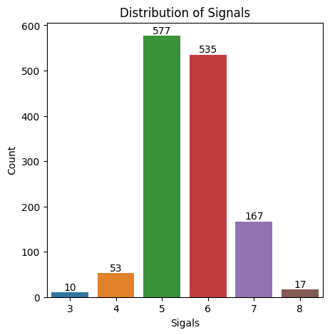

```python
plt.figure(figsize=(5, 5))
ax=sns.barplot(x=signal_distribution.index, y=signal_distribution.values)
ax.bar_label(ax.containers[0])

plt.xlabel('Sigals')
plt.ylabel('Count')
plt.title('Distribution of Signals')
plt.show()
```

```python
def  box_plot(df):
  cat_columns = []
  for i in df.columns:
    if (((df[i].dtype.name) == 'float64') ):
      cat_columns.append(i)
  ncols = 3
  nrows = len(cat_columns) // ncols + (len(cat_columns) % ncols > 0)
  plt.figure(figsize=(30,30))
  for i, j in enumerate(cat_columns):
    plt.subplot(nrows, ncols, i+1)
    ax=sns.boxplot(df[j],color='blue')
    ax.set_title("boxplot of "+j)
  return plt.show()
```

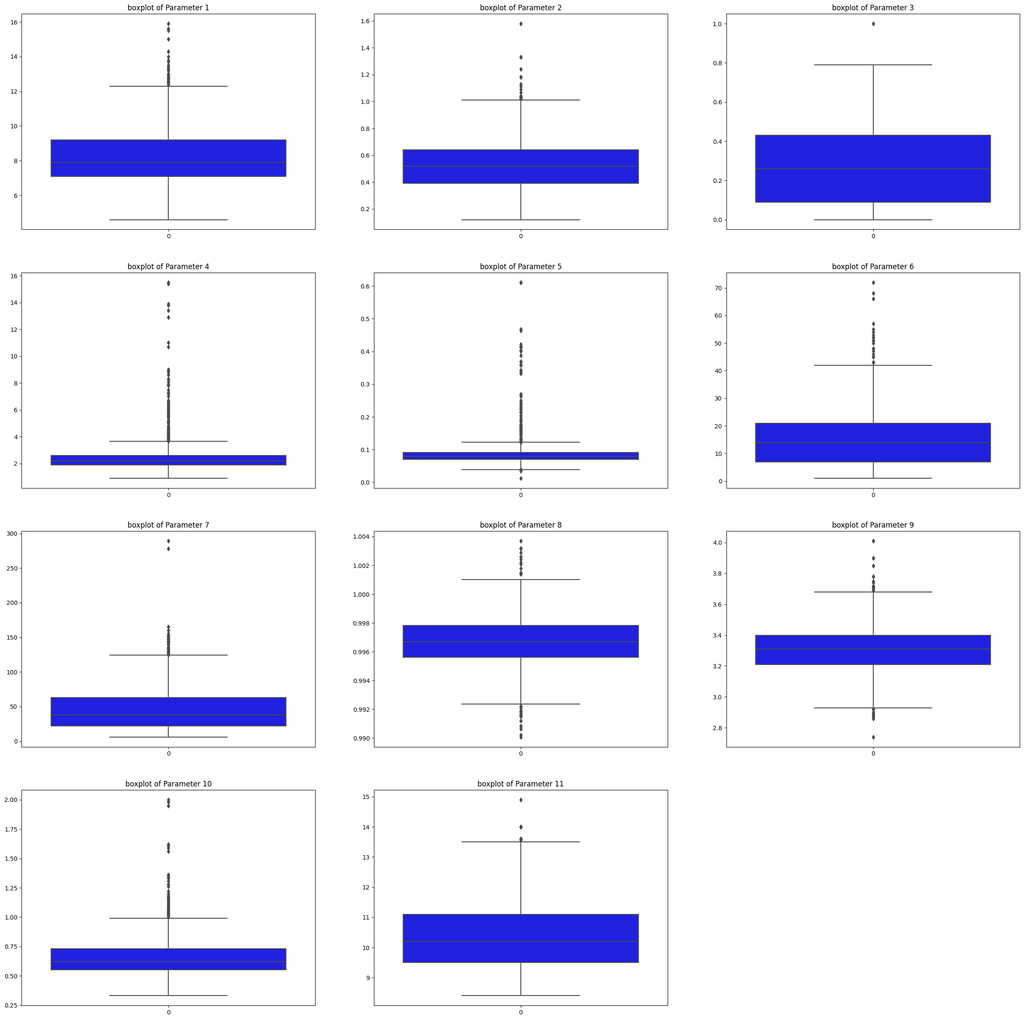

```python
box_plot(df_signal)
```

Data set contains many outliers. Fixing the outliers.

```python
for i in df_signal.columns:
    if (((df_signal[i].dtype.name) == 'float64') ):
      Q1=df_signal[i].quantile(0.25)
      Q3=df_signal[i].quantile(0.75)
      IQR=Q3-Q1
      lower = Q1 - 1.5*IQR
      upper = Q3 + 1.5*IQR
      median = df_signal[i].median()
      df_signal[i][df_signal[i] < lower] = median
      df_signal[i][df_signal[i] > upper] = median
```

Again plot boxplot, to check the structures and outliers.

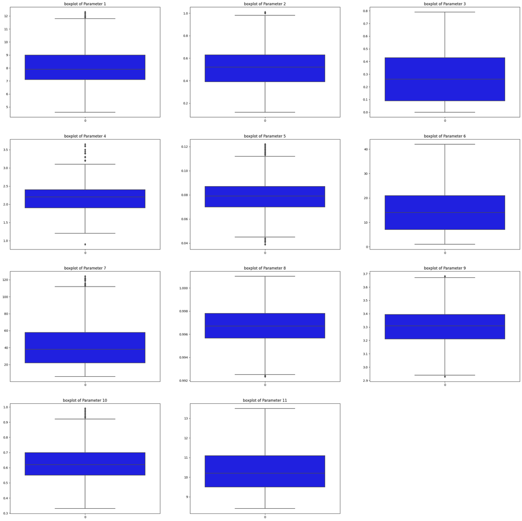

```python
box_plot(df_signal)
```

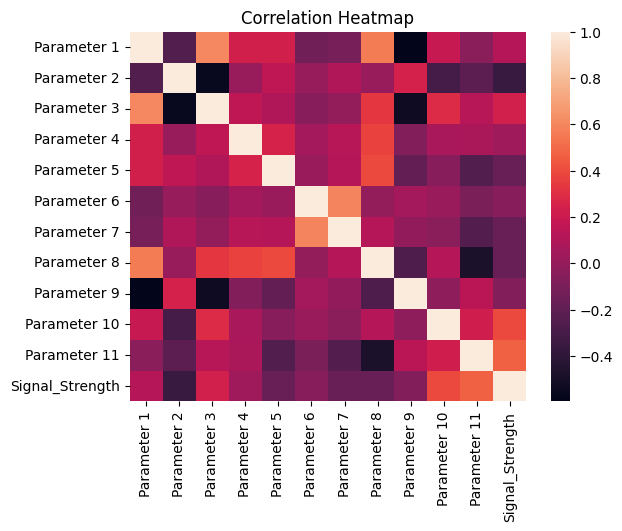

```python
sns.heatmap(df_signal.corr() )
plt.title("Correlation Heatmap")
plt.show()
```

**1 E. Share insights from the initial data analysis .**

**2.Data preprocessing**

1. **2.A Split the data into X & Y.**
2. **2.B Split the data into train & test with 70:30 proportion.**
3. **2.C Print shape of all the 4 variables and verify if train and test data is in sync.**
4. **2.D Normalise the train and test data with appropriate method.**

```python
#signal strengt type is int64 , changing ibto categorical data
df_signal['Signal_Strength'] = pd.Categorical(df_signal['Signal_Strength'])
# Convert in feature and target variables
X = df_signal.drop(['Signal_Strength'],axis=1)
Y = df_signal['Signal_Strength']
```

```python
Y.info()
```

```
<class 'pandas.core.series.Series'>
Int64Index: 1359 entries, 0 to 1598
Series name: Signal_Strength
Non-Null Count  Dtype
--------------  -----
1359 non-null   category
dtypes: category(1)
memory usage: 44.4 KB
```

```python
X_normalized = zscore(X)
```

```python
X_normalized.head()
```

|  | Parameter 1 | Parameter 2 | Parameter 3 | Parameter 4 | Parameter 5 | Parameter 6 | Parameter 7 | Parameter 8 | Parameter 9 | Parameter 10 | Parameter 11 |
| --- | --- | --- | --- | --- | --- | --- | --- | --- | --- | --- | --- |
| 0 | -0.501477 | 1.069569 | -1.397620 | -0.665907 | -0.185137 | -0.457161 | -0.338526 | 0.661020 | 1.450976 | -0.637058 | -0.970086 |
| 1 | -0.233957 | 2.144631 | -1.397620 | 0.943334 | 1.276890 | 1.074438 | 0.872006 | 0.054809 | -0.768235 | 0.387917 | -0.581895 |
| 2 | -0.233957 | 1.427923 | -1.191928 | 0.253659 | 0.878155 | -0.019562 | 0.395130 | 0.176051 | -0.338710 | 0.131673 | -0.581895 |
| 3 | 2.039962 | -1.438910 | 1.482077 | -0.665907 | -0.251593 | 0.199238 | 0.615226 | 0.782263 | -1.054585 | -0.466229 | -0.581895 |
| 5 | -0.501477 | 0.830666 | -1.397620 | -0.895799 | -0.251593 | -0.238361 | -0.118430 | 0.661020 | 1.450976 | -0.637058 | -0.970086 |

```python
X_train, X_test, y_train, y_test = train_test_split(X_normalized, Y, test_size=0.3, random_state=1)
```

```python
print(X_train.shape)
print(X_test.shape)
print(y_train.shape)
print(y_test.shape)
```

```
(951, 11)
(408, 11)
(951,)
(408,)
```

```python
print('Original dataset shape {}'.format(Counter(Y)))
print('After Over sampling shape {}'.format(Counter(y_train)))
print('Resampled dataset shape {}'.format(Counter(y_test)))
```

```
Original dataset shape Counter({5: 577, 6: 535, 7: 167, 4: 53, 8: 17, 3: 10})
After Over sampling shape Counter({5: 410, 6: 363, 7: 123, 4: 34, 8: 14, 3: 7})
Resampled dataset shape Counter({6: 172, 5: 167, 7: 44, 4: 19, 3: 3, 8: 3})
```

Number of rows and columns are in sync wrt test and train data. Data is not balanced.

```python
y_train = pd.get_dummies(y_train)
y_test = pd.get_dummies(y_test)
```

```python
y_train[:5]
```

|  | 3 | 4 | 5 | 6 | 7 | 8 |
| --- | --- | --- | --- | --- | --- | --- |
| 303 | 0 | 0 | 1 | 0 | 0 | 0 |
| 1292 | 0 | 0 | 0 | 1 | 0 | 0 |
| 695 | 0 | 0 | 0 | 1 | 0 | 0 |
| 451 | 0 | 0 | 0 | 1 | 0 | 0 |
| 1309 | 0 | 0 | 1 | 0 | 0 | 0 |

```python
y_test[:5]
```

|  | 3 | 4 | 5 | 6 | 7 | 8 |
| --- | --- | --- | --- | --- | --- | --- |
| 473 | 0 | 0 | 1 | 0 | 0 | 0 |
| 1376 | 0 | 0 | 1 | 0 | 0 | 0 |
| 533 | 0 | 0 | 0 | 1 | 0 | 0 |
| 200 | 0 | 0 | 0 | 0 | 1 | 0 |
| 268 | 0 | 0 | 0 | 1 | 0 | 0 |

**3 Model Training & Evaluation using Neural Network**

**3 A Design a Neural Network to train a classifier**

```python
import tensorflow
from tensorflow.keras import losses
from tensorflow.keras import optimizers
from tensorflow.keras import Sequential
from tensorflow.keras.layers import Dense
from tensorflow.keras.layers import Dropout
from tensorflow.keras.layers import BatchNormalization
from tensorflow.keras.callbacks import ModelCheckpoint, ReduceLROnPlateau
from tensorflow.keras import backend
```

```python
epochs =100
backend.clear_session()
import random
random.seed(42)
output_nodes=6
learning_rate=.001
```

**Single layer Neural network**

```python
def single_layer(output_nodes):

  model = Sequential()
  model.add(Dense(256, activation='relu',kernel_initializer='he_uniform',input_dim = X_train.shape[1] ))
  model.add(Dense(output_nodes, activation='softmax'))
  #compile mode-
  adam = optimizers.Adam(learning_rate=1e-3)
  model.compile(loss=losses.categorical_crossentropy, optimizer=adam, metrics=['accuracy'])
  return model

checkpoint = ModelCheckpoint("model.weights.h5",monitor='val_accuracy',
                            save_weights_only=True, mode='max',verbose=0)
reduce_lr = ReduceLROnPlateau(monitor='val_loss',factor=0.1,patience=2,min_lr=0.001,model='auto')
callbacks = [checkpoint,reduce_lr]
model= single_layer(output_nodes)
print(model.summary())
```

```
Model: "sequential"
_________________________________________________________________
 Layer (type)                Output Shape              Param #
=================================================================
 dense (Dense)               (None, 256)               3072

 dense_1 (Dense)             (None, 6)                 1542

=================================================================
Total params: 4,614
Trainable params: 4,614
Non-trainable params: 0
_________________________________________________________________
None
```

**3.B. Train the classifier using previously designed Architecture**

```python
NN=model.fit(X_train, y_train, validation_split=0.2, epochs=epochs, batch_size=200, verbose=0,callbacks=callbacks)
results = model.evaluate(X_test, y_test)
result_loss=results[0]
result_accuracy=results[1]
print("Loss on test data",result_loss)
print("Accuracy on test data", result_accuracy)
```

```
Loss on test data 1.184011697769165
Accuracy on test data 0.5343137383460999
```

**3.C Plot Training Loss and Validation Loss**

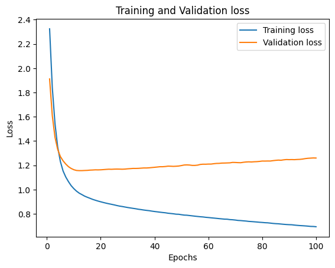

```python
loss_train = NN.history['loss']
loss_val = NN.history['val_loss']
epochs = range(1,101)
plt.plot(epochs, loss_train,  label='Training loss')
plt.plot(epochs, loss_val, label='Validation loss')
plt.title('Training and Validation loss')
plt.xlabel('Epochs')
plt.ylabel('Loss')
plt.legend()
plt.show()
```

**3.C.ii Training Accuracy and Validation Accuracy**

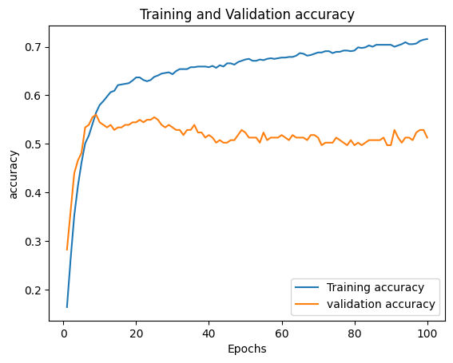

```python
Acc_train = NN.history['accuracy']
Acc_val = NN.history['val_accuracy']
epochs_range = range(1,101)
plt.plot(epochs_range, Acc_train, label='Training accuracy')
plt.plot(epochs_range, Acc_val, label='validation accuracy')
plt.title('Training and Validation accuracy')
plt.xlabel('Epochs')
plt.ylabel('accuracy')
plt.legend()
plt.show()
```

**4D. Design new architecture/update existing architecture in attempt to improve the performance of the model.**

```python
epochs=100
from tensorflow.keras.layers import Activation, Dense
backend.clear_session()
def multilayer_sigmoids_sgd(output_nodes):
  model = Sequential()
  model.add(Dense(50, input_dim = X_train.shape[1]))
  model.add(Activation('sigmoid'))
  model.add(Dense(50))
  model.add(Activation('sigmoid'))
  model.add(Dense(50))
  model.add(Activation('sigmoid'))
  model.add(Dense(50))
  model.add(Activation('sigmoid'))
  model.add(Dense(output_nodes))
  model.add(Activation('softmax'))
  sgd = optimizers.SGD(learning_rate = learning_rate)
  model.compile(optimizer = sgd, loss = 'categorical_crossentropy', metrics = ['accuracy'])
  return model
```

```python
backend.clear_session()
def multilayer_tanh_sgd_henormal(output_nodes):
    model = Sequential()

    model.add(Dense(50, input_dim = X_train.shape[1], kernel_initializer='he_normal'))
    model.add(Activation('tanh'))
    model.add(Dense(50, kernel_initializer='he_normal'))
    model.add(Activation('tanh'))
    model.add(Dense(50, kernel_initializer='he_normal'))
    model.add(Activation('tanh'))
    model.add(Dense(50, kernel_initializer='he_normal'))
    model.add(Activation('tanh'))
    model.add(Dense(output_nodes, kernel_initializer='he_normal'))
    model.add(Activation('softmax'))

    sgd = optimizers.SGD(learning_rate = learning_rate)
    model.compile(optimizer = sgd, loss = 'categorical_crossentropy', metrics = ['accuracy'])

    return model
```

```python
backend.clear_session()
def multilayer_relu_sgd(output_nodes):
    model = Sequential()

    model.add(Dense(50 ,input_dim = X_train.shape[1]))
    model.add(Activation('relu'))
    model.add(Dense(50))
    model.add(Activation('relu'))
    model.add(Dense(50))
    model.add(Activation('relu'))
    model.add(Dense(50))
    model.add(Activation('relu'))
    model.add(Dense(output_nodes))
    model.add(Activation('softmax'))

    sgd = optimizers.SGD(learning_rate = learning_rate)
    model.compile(optimizer = sgd, loss = 'categorical_crossentropy', metrics = ['accuracy'])

    return model
```

```python
backend.clear_session()
def multilayer_relu_dropouts_adam(output_nodes):
  model = Sequential()
  model.add(Dense(256,activation='relu',input_dim = X_train.shape[1]))
  model.add(Dropout(0.2))
  model.add(Dense(128,activation='relu'))
  model.add(Dropout(0.2))
  model.add(Dense(64,activation='relu'))
  model.add(Dropout(0.2))
  model.add(Dense(32,activation='relu'))
  model.add(Dense(output_nodes, activation = 'softmax'))
  optimizer = optimizers.Adam(learning_rate)
  model.compile(loss='categorical_crossentropy',optimizer=optimizer,metrics=['accuracy'])
  return model

model= multilayer_relu_dropouts_adam(output_nodes)
```

```python
#batch normalization
def multilayer_relu_batchnormalization(output_nodes):
    model = Sequential()
    model.add(Dense(50, input_dim = X_train.shape[1]))
    model.add(BatchNormalization())
    model.add(Activation('relu'))
    model.add(Dense(50))
    model.add(BatchNormalization())
    model.add(Activation('relu'))
    model.add(Dense(50))
    model.add(BatchNormalization())
    model.add(Activation('relu'))
    model.add(Dense(50))
    model.add(BatchNormalization())
    model.add(Activation('relu'))
    model.add(Dense(output_nodes))
    model.add(Activation('softmax'))
    sgd = optimizers.SGD(learning_rate = learning_rate)
    model.compile(optimizer = sgd, loss = 'categorical_crossentropy', metrics = ['accuracy'])
    return model
model = multilayer_relu_batchnormalization(output_nodes)
```

```python
def complicated_model(output_nodes):
    model = Sequential()
    model.add(Dense(50, input_dim = X_train.shape[1], kernel_initializer='he_normal'))
    model.add(BatchNormalization())
    model.add(Activation('relu'))
    model.add(Dropout(0.2))
    model.add(Dense(50, kernel_initializer='he_normal'))
    model.add(BatchNormalization())
    model.add(Activation('relu'))
    model.add(Dropout(0.2))
    model.add(Dense(50, kernel_initializer='he_normal'))
    model.add(BatchNormalization())
    model.add(Activation('relu'))
    model.add(Dropout(0.2))
    model.add(Dense(50, kernel_initializer='he_normal'))
    model.add(BatchNormalization())
    model.add(Activation('relu'))
    model.add(Dropout(0.2))
    model.add(Dense(output_nodes, kernel_initializer='he_normal'))
    model.add(Activation('softmax'))
    adam = optimizers.Adam(learning_rate = learning_rate)
    model.compile(optimizer = adam, loss = 'categorical_crossentropy', metrics = ['accuracy'])
    return model
```

```python
from tensorflow.keras.models import Sequential
from tensorflow.keras.layers import Dense, LeakyReLU

epochs=100
def lekyRelu_fun(output_nodes):
    model = Sequential()
    model.add(Dense(128, kernel_initializer='normal', input_dim=X_train.shape[1], activation='sigmoid'))
    model.add(Dense(64, kernel_initializer='normal', activation='sigmoid'))
    model.add(Dense(32, kernel_initializer='normal'))
    model.add(LeakyReLU(alpha=0.1))
    model.add(Dense(16, kernel_initializer='normal'))
    model.add(LeakyReLU(alpha=0.1))
    model.add(Dense(output_nodes, kernel_initializer='normal', activation='softmax'))
    model.compile(loss='categorical_crossentropy', optimizer='adam', metrics=['accuracy'])
    return model
```

```python
dataset_analysis = pd.DataFrame(columns=['model_name','test_loss', 'test_accuracy', 'training loss', 'training accuracy','val loss', 'val accuracy'])
def table(model, NN, model_name):
    # Evaluate the model on the test set
    results = model.evaluate(X_test, y_test)
    test_loss=results[0]
    test_accuracy=results[1]

    # Calculate training accuracy and loss
    training_accuracy = np.mean(NN.history['accuracy'])
    training_loss = np.mean(NN.history['loss'])

    # Calculate validation accuracy and loss
    val_accuracy = np.mean(NN.history['val_accuracy'])
    val_loss = np.mean(NN.history['val_loss'])

    # Add a new row to the DataFrame
    global dataset_analysis
    dataset_analysis = dataset_analysis.append({'model_name':model_name,
                                                'test_loss': test_loss,
                                                'test_accuracy': test_accuracy,
                                                'training loss': training_loss,
                                                'training accuracy': training_accuracy,
                                                'val loss': val_loss,
                                                'val accuracy': val_accuracy
                                                                  },
                                               ignore_index=True)
```

```python
backend.clear_session()
model= single_layer(6)
NN=model.fit(X_train, y_train, validation_split=0.2, epochs=epochs,verbose=0, batch_size=200)
table(model,NN,'Single_layer')

###########################Multilayed_sigmoids_sgd()
backend.clear_session()
model =multilayer_sigmoids_sgd(6)
NN = model.fit(X_train, y_train, validation_split=0.2, batch_size = 200, epochs = epochs, verbose=0)
table(model,NN,'multilayer_sigmoids_sgd')

############################Multilayer_tanh_sgd_henormal()
backend.clear_session()
model = multilayer_tanh_sgd_henormal(6)
NN = model.fit(X_train, y_train, batch_size=200, validation_split=0.2, epochs = epochs, verbose = 0)
table(model,NN,'multilayer_tanh_sgd_henormal')

##############################
backend.clear_session()
model = multilayer_relu_sgd(6)
NN = model.fit(X_train, y_train, epochs = epochs, verbose = 0,batch_size=200, validation_split=0.2)
table(model,NN,'Multilayer_relu_sgd')

##################################################################
backend.clear_session()
model = multilayer_relu_dropouts_adam(6)
NN = model.fit(X_train, y_train, epochs = epochs, verbose = 0,batch_size=200, validation_split=0.2)
table(model,NN,'multilayer_relu_dropouts_adam')

##################################multilayer_relu_batchnormalization
backend.clear_session()
model = multilayer_relu_batchnormalization(6)
NN = model.fit(X_train, y_train, epochs = epochs, verbose = 0, batch_size=200, validation_split=0.2)
table(model,NN,'multilayer_relu_batchnormalization')

########################lekyRelu_fun()
backend.clear_session()
model = lekyRelu_fun(6)
NN = model.fit(X_train, y_train, epochs=epochs, verbose=0,batch_size=200, validation_split=0.2)
table(model,NN,'lekyRelu')

###################################################
backend.clear_session()
model = complicated_model(6)
NN = model.fit(X_train, y_train, epochs = epochs , verbose = 0,batch_size=200, validation_split=0.2)
table(model,NN,'complicated_model')

dataset_analysis
```

|  | model_name | test_loss | test_accuracy | training loss | training accuracy | val loss | val accuracy |
| --- | --- | --- | --- | --- | --- | --- | --- |
| 0 | Single_layer | 1.215146 | 0.536765 | 0.830030 | 0.661724 | 1.237331 | 0.497016 |
| 1 | multilayer_sigmoids_sgd | 1.347151 | 0.409314 | 1.577928 | 0.360868 | 1.602657 | 0.353979 |
| 2 | multilayer_tanh_sgd_henormal | 1.573523 | 0.397059 | 1.743827 | 0.273434 | 1.797440 | 0.227277 |
| 3 | Multilayer_relu_sgd | 1.427531 | 0.500000 | 1.528062 | 0.508342 | 1.555676 | 0.495393 |
| 4 | multilayer_relu_dropouts_adam | 1.432928 | 0.566176 | 0.808582 | 0.664132 | 1.212516 | 0.547173 |
| 5 | multilayer_relu_batchnormalization | 1.563590 | 0.392157 | 1.865367 | 0.231776 | 1.766763 | 0.193822 |
| 6 | lekyRelu | 1.098990 | 0.536765 | 1.198480 | 0.450395 | 1.269494 | 0.438115 |
| 7 | complicated_model | 1.070111 | 0.526961 | 1.111932 | 0.561697 | 1.210714 | 0.507330 |

**Insight** :

1. The data is imbalanced.
2. The accuracy is average on test data (52%-57%) on few models like Single hidden layer with relu activation with adam optimizer and multiple layer with relu activation with batchnormlaization and dropout model.
3. To improve the accuracy , executing the models on balancedata set.

**Balancing the data with Random overler**

```python
from imblearn.over_sampling import RandomOverSampler
ROS =  RandomOverSampler()
X_ros1, y_ros1 = ROS.fit_resample(X_normalized,Y)
X_train, X_test, y_train, y_test = train_test_split(X_ros1, y_ros1, test_size=0.2, random_state=1)
```

```python
print('Original dataset shape {}'.format(Counter(Y)))
print('After Over sampling shape {}'.format(Counter(y_ros1)))
print('Resampled dataset shape {}'.format(Counter(y_train)))
print('Resampled dataset shape {}'.format(Counter(y_test)))
```

```
Original dataset shape Counter({5: 577, 6: 535, 7: 167, 4: 53, 8: 17, 3: 10})
After Over sampling shape Counter({5: 577, 6: 577, 7: 577, 4: 577, 8: 577, 3: 577})
Resampled dataset shape Counter({7: 470, 3: 467, 6: 459, 5: 459, 8: 459, 4: 455})
Resampled dataset shape Counter({4: 122, 5: 118, 8: 118, 6: 118, 3: 110, 7: 107})
```

```python
y_train = pd.get_dummies(y_train)
y_test = pd.get_dummies(y_test)
epochs =100
backend.clear_session()
np.random.seed(42)
import random
random.seed(42)
model_name=''
```

```python
balanced_dataset_analysis = pd.DataFrame(columns=['model_name','test_loss', 'test_accuracy', 'training loss', 'training accuracy', 'val loss', 'val accuracy'])

def table2(model, NN, model_name):
    # Evaluate the model on the test set
    results = model.evaluate(X_test, y_test)
    test_loss=results[0]
    test_accuracy=results[1]

    # Calculate training accuracy and loss
    training_accuracy = np.mean(NN.history['accuracy'])
    training_loss = np.mean(NN.history['loss'])

    # Calculate validation accuracy and loss
    val_accuracy = np.mean(NN.history['val_accuracy'])
    val_loss = np.mean(NN.history['val_loss'])

    # Add a new row to the DataFrame
    global balanced_dataset_analysis
    balanced_dataset_analysis = balanced_dataset_analysis.append({'model_name':model_name,
                                                'test_loss': test_loss,
                                                'test_accuracy': test_accuracy,
                                                'training loss': training_loss,
                                                'training accuracy': training_accuracy,
                                                'val loss': val_loss,
                                                'val accuracy': val_accuracy
                                                                  },
                                               ignore_index=True)
```

```python
backend.clear_session()
model= single_layer(6)
NN=model.fit(X_train, y_train, validation_split=0.2, epochs=100,verbose=0, batch_size=200)
table2(model,NN,'Single_layer')

###########################Multilayed_sigmoids_sgd()
backend.clear_session()
model =multilayer_sigmoids_sgd(6)
NN = model.fit(X_train, y_train, batch_size = 200, epochs = 100, verbose=0, validation_split=0.2)
table2(model,NN,'multilayer_sigmoids_sgd')

###########################Multilayer_tanh_sgd_henormal()
backend.clear_session()
model = multilayer_tanh_sgd_henormal(6)
NN = model.fit(X_train, y_train, batch_size=200, epochs = epochs, verbose = 0, validation_split=0.2)
table2(model,NN,'multilayer_tanh_sgd_henormal')
##############################
backend.clear_session()
model = multilayer_relu_sgd(6)
NN = model.fit(X_train, y_train, epochs = epochs, verbose = 0, validation_split=0.2, batch_size=200)
table2(model,NN,'Multilayer_relu_sgd')
##################################################################
backend.clear_session()
model = multilayer_relu_dropouts_adam(6)
NN = model.fit(X_train, y_train, epochs = epochs, verbose = 0, validation_split=0.2,batch_size=200)
table2(model,NN,'multilayer_relu_dropouts_adam')
##################################multilayer_relu_batchnormalization
backend.clear_session()
model = multilayer_relu_batchnormalization(6)
NN = model.fit(X_train, y_train, epochs = epochs, verbose = 0,batch_size=200, validation_split=0.2)
table2(model,NN,'multilayer_relu_batchnormalization')
########################lekyRelu_fun()
backend.clear_session()
model = lekyRelu_fun(6)
NN = model.fit(X_train, y_train, epochs=epochs, verbose=0,batch_size=200, validation_split=0.2)
table2(model,NN,'lekyRelu')
###################################################
backend.clear_session()
model = complicated_model(6)
NN = model.fit(X_train, y_train, epochs = epochs , verbose = 0, batch_size=200, validation_split=0.2)
table2(model,NN,'complicated_model')
balanced_dataset_analysis
```

|  | model_name | test_loss | test_accuracy | training loss | training accuracy | val loss | val accuracy |
| --- | --- | --- | --- | --- | --- | --- | --- |
| 0 | Single_layer | 0.601400 | 0.776335 | 0.721507 | 0.741648 | 0.758495 | 0.720469 |
| 1 | multilayer_sigmoids_sgd | 1.791576 | 0.132756 | 1.815839 | 0.155160 | 1.801532 | 0.163339 |
| 2 | multilayer_tanh_sgd_henormal | 1.355430 | 0.493506 | 1.614075 | 0.364411 | 1.559907 | 0.383935 |
| 3 | Multilayer_relu_sgd | 1.722935 | 0.301587 | 1.767420 | 0.237255 | 1.775582 | 0.194892 |
| 4 | multilayer_relu_dropouts_adam | 0.428735 | 0.822511 | 0.593050 | 0.759422 | 0.563745 | 0.766011 |
| 5 | multilayer_relu_batchnormalization | 1.133703 | 0.577201 | 1.371214 | 0.482248 | 1.351315 | 0.483159 |
| 6 | lekyRelu | 1.165184 | 0.461760 | 1.266478 | 0.440560 | 1.260568 | 0.457166 |
| 7 | complicated_model | 0.736659 | 0.683983 | 1.132452 | 0.534885 | 0.916898 | 0.635686 |

multilayer_relu_dropouts_adam models gives the best accuracy on test data around 81%. So performing the perfromance analysis on the same model.

**3.E Plot visuals as in Q3.C and share insights about difference observed in both the models**

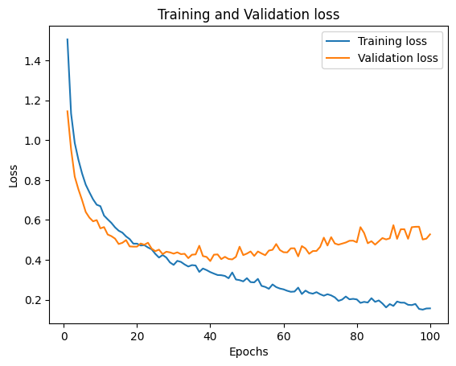

```python
model = multilayer_relu_dropouts_adam(6)
NN = model.fit(X_train, y_train, epochs = epochs,validation_split=.2)
loss_train = NN.history['loss']
loss_val = NN.history['val_loss']
epochs = range(1,101)
plt.plot(epochs, loss_train,  label='Training loss')
plt.plot(epochs, loss_val, label='Validation loss')
plt.title('Training and Validation loss')
plt.xlabel('Epochs')
plt.ylabel('Loss')
plt.legend()
plt.show()
```

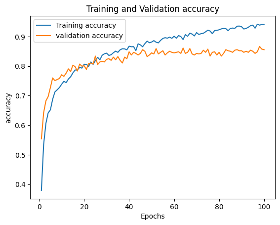

```python
Acc_train = NN.history['accuracy']
Acc_val = NN.history['val_accuracy']
epochs_range = range(1,101)
plt.plot(epochs_range, Acc_train, label='Training accuracy')
plt.plot(epochs_range, Acc_val, label='validation accuracy')
plt.title('Training and Validation accuracy')
plt.xlabel('Epochs')
plt.ylabel('accuracy')
plt.legend()
plt.show()
```

```python
print("Acc_train",np.mean(Acc_train))
print("Acc_val", np.mean(Acc_val))
print("loss_train",np.mean(loss_train))
print("loss_val",np.mean(loss_val))
results = model.evaluate(X_test, y_test)
test_loss=results[0]
test_accuracy=results[1]
```

```
Acc_train 0.8533634305000305
Acc_val 0.8221480107307434
loss_train 0.3619601933658123
loss_val 0.49624251276254655
```

**Part B**

**1. Data Import and Exploration**

**A. Read the .h5 file and assign to a variable. [**

```python
import h5py
import pandas as pd
import numpy as np
import keras
from tensorflow.keras.utils import to_categorical
import warnings
warnings.filterwarnings('ignore')
from tensorflow.keras.callbacks import ModelCheckpoint, ReduceLROnPlateau
from tensorflow.keras import losses
from tensorflow.keras import optimizers
from tensorflow.keras import Sequential
from tensorflow.keras.layers import Dense
from tensorflow.keras.layers import Dropout
from tensorflow.keras.layers import BatchNormalization
from tensorflow.keras.callbacks import ModelCheckpoint, ReduceLROnPlateau
from tensorflow.keras import backend
import tensorflow
np.random.seed(42)
tensorflow.random.set_seed(42)
```

```python
file_path = '/content/drive/MyDrive/Colab Notebooks/Autonomous_Vehicles_SVHN_single_grey1.h5'
h5f = h5py.File(file_path,'r')
```

**B. Print all the keys from the .h5 file.**

```python
print(h5f.keys())
```

```
<KeysViewHDF5 ['X_test', 'X_train', 'X_val', 'y_test', 'y_train', 'y_val']>
```

**C. Split the data into X_train, X_test, Y_train, Y_test**

```python
#training set
X_train = h5f['X_train'][:]
y_train = h5f['y_train'][:]
#test set
X_test = h5f['X_test'][:]
y_test = h5f['y_test'][:]
#validation set
X_val = h5f['X_val'][:]
y_val = h5f['y_val'][:]
```

**Data Visualisation and preprocessing**

1. **. Print shape of all the 4 data split into x, y, train, test to verify if x & y is in sync**

```python
#X dataset
print("Shape of training data set is=", X_train.shape)
print("Shape of test data set is=", X_test.shape)
print("Shape of val data set is=", X_val.shape)
#Y dataset
print("Shape of training data set is=", y_train.shape)
print("Shape of test data set is=", y_test.shape)
print("Shape of val data set is=", y_val.shape)
```

```
Shape of training data set is= (42000, 32, 32)
Shape of test data set is= (18000, 32, 32)
Shape of val data set is= (60000, 32, 32)
Shape of training data set is= (42000,)
Shape of test data set is= (18000,)
Shape of val data set is= (60000,)
```

1. **Visualise first 10 images in train data and print its corresponding labels.**

```
label for each of the above image: [2 6 7 4 4 0 3 0 7 3]
```

```python
%matplotlib inline
import matplotlib.pyplot as plt
plt.figure(figsize=(10, 1))
for i in range(10):
    plt.subplot(1, 10, i+1)
    plt.imshow(X_train[i], cmap="gray")
    plt.axis('off')
plt.show()
print('label for each of the above image: %s' % (y_train[0:10]))
```

[output not shown]

3.**Reshape all the images with appropriate shape update the data in same variable**

```python
image_vector_size=32*32
X_train = X_train.reshape(X_train.shape[0], image_vector_size)
X_test = X_test.reshape(X_test.shape[0], image_vector_size)
X_val= X_val.reshape(X_val.shape[0], image_vector_size)
```

1. **Normalise the images i.e. Normalise the pixel values**

```python
x_train = X_train / 255.0
x_test = X_test / 255.0
x_val= X_val/255.0

print('Training set', x_train.shape, y_train.shape)
print('Test set', x_test.shape, y_test.shape)
```

```
Training set (42000, 1024) (42000,)
Test set (18000, 1024) (18000,)
```

5.**Print total Number of classes in the Dataset**

```python
unique_elements_test = np.unique(y_test)
unique_elements_train = np.unique(y_train)
print("Total number of classes or unique elements in y test dataset",unique_elements_test)
print("Total number of classes or unique elements in y train dataset",unique_elements_train)
num_classes=len(unique_elements_test)
print("Total clases count=",num_classes )
```

```
Total number of classes or unique elements in y test dataset [0 1 2 3 4 5 6 7 8 9]
Total number of classes or unique elements in y train dataset [0 1 2 3 4 5 6 7 8 9]
Total clases count= 10
```

1. **Transform Labels into format acceptable by Neural Network**

```python
y_train = to_categorical(y_train)
y_test_cat=to_categorical(y_test)
y_val=to_categorical(y_val)
```

**Model Training & Evaluation using Neural Network**

```python
#Transform Labels into format acceptable by Neural Network
```

```python
image_size=32*32
epochs=100
output_nodes=10
```

```python
def single_layer(output_nodes):

  model = Sequential()
  model.add(Dense(256, activation='sigmoid',kernel_initializer='he_uniform',input_dim = X_train.shape[1] ))
  model.add(Dense(output_nodes, activation='softmax'))
  #compile mode-
  adam = optimizers.Adam(learning_rate=1e-3)
  model.compile(loss=losses.categorical_crossentropy, optimizer=adam, metrics=['accuracy'])
  return model

checkpoint = ModelCheckpoint("model.weights.h5",monitor='accuracy',
                            save_weights_only=True, mode='max',verbose=0)
reduce_lr = ReduceLROnPlateau(monitor='accuracy',factor=0.1,patience=2,min_lr=0.001,model='auto')
callbacks = [checkpoint,reduce_lr]
model= single_layer(output_nodes)
print(model.summary())
```

```
Model: "sequential_2"
_________________________________________________________________
 Layer (type)                Output Shape              Param #
=================================================================
 dense_10 (Dense)            (None, 256)               262400

 dense_11 (Dense)            (None, 10)                2570

=================================================================
Total params: 264,970
Trainable params: 264,970
Non-trainable params: 0
_________________________________________________________________
None
```

```python
model.fit(x_train, y_train, epochs=100,verbose=0, batch_size=1000,validation_data=(x_val, y_val),callbacks=callbacks)
results = model.evaluate(x_test, y_test_cat)
result_loss=results[0]
result_accuracy=results[1]
print(" test loss =", result_loss)
print(" test accuracy =", result_accuracy)
```

```
 test loss = 0.7074545621871948
 test accuracy = 0.7896666526794434
```

Performance is not good. So trying some other models below

```python
from tensorflow.keras.layers import Activation, Dense
backend.clear_session()
def multilayer_sigmoids_sgd(output_nodes):
  model = Sequential()
  model.add(Dense(50, input_dim = X_train.shape[1]))
  model.add(Activation('sigmoid'))
  model.add(Dense(50))
  model.add(Activation('sigmoid'))
  model.add(Dense(50))
  model.add(Activation('sigmoid'))
  model.add(Dense(50))
  model.add(Activation('sigmoid'))
  model.add(Dense(output_nodes))
  model.add(Activation('softmax'))
  sgd = optimizers.SGD(learning_rate = learning_rate)
  model.compile(optimizer = sgd, loss = 'categorical_crossentropy', metrics = ['accuracy'])
  return model
```

```python
backend.clear_session()
def multilayer_tanh_sgd_henormal(output_nodes):
    model = Sequential()

    model.add(Dense(50, input_dim = X_train.shape[1], kernel_initializer='he_normal'))
    model.add(Activation('tanh'))
    model.add(Dense(50, kernel_initializer='he_normal'))
    model.add(Activation('tanh'))
    model.add(Dense(50, kernel_initializer='he_normal'))
    model.add(Activation('tanh'))
    model.add(Dense(50, kernel_initializer='he_normal'))
    model.add(Activation('tanh'))
    model.add(Dense(output_nodes))

    sgd = optimizers.SGD(learning_rate = learning_rate)
    model.compile(optimizer = sgd, loss = 'categorical_crossentropy', metrics = ['accuracy'])

    return model
```

```python
backend.clear_session()
def multilayer_relu_sgd(output_nodes):
    model = Sequential()

    model.add(Dense(50 ,input_dim = X_train.shape[1]))
    model.add(Activation('relu'))
    model.add(Dense(50))
    model.add(Activation('relu'))
    model.add(Dense(50))
    model.add(Activation('relu'))
    model.add(Dense(50))
    model.add(Activation('relu'))
    model.add(Dense(output_nodes))
    model.add(Activation('softmax'))

    sgd = optimizers.SGD(learning_rate = learning_rate)
    model.compile(optimizer = sgd, loss = 'categorical_crossentropy', metrics = ['accuracy'])
    return model
```

```python
backend.clear_session()
def multilayer_relu_dropouts_adam(output_nodes):
  model = Sequential()
  model.add(Dense(256,activation='relu',input_dim = X_train.shape[1]))
  model.add(Dropout(0.2))
  model.add(Dense(128,activation='relu'))
  model.add(Dropout(0.2))
  model.add(Dense(64,activation='relu'))
  model.add(Dropout(0.2))
  model.add(Dense(32,activation='relu'))
  model.add(Dense(output_nodes, activation = 'softmax'))
  optimizer = optimizers.Adam(learning_rate)
  model.compile(loss='categorical_crossentropy',optimizer=optimizer,metrics=['accuracy'])
  return model
```

```python
#batch normalization
def multilayer_relu_batchnormalization(output_nodes):
    model = Sequential()
    model.add(Dense(50, input_dim = X_train.shape[1]))
    model.add(BatchNormalization())
    model.add(Activation('relu'))
    model.add(Dense(50))
    model.add(BatchNormalization())
    model.add(Activation('relu'))
    model.add(Dense(50))
    model.add(BatchNormalization())
    model.add(Activation('relu'))
    model.add(Dense(50))
    model.add(BatchNormalization())
    model.add(Activation('relu'))
    model.add(Dense(output_nodes))
    model.add(Activation('softmax'))
    sgd = optimizers.SGD(learning_rate = learning_rate)
    model.compile(optimizer = sgd, loss = 'categorical_crossentropy', metrics = ['accuracy'])
    return model
```

```python
def complicated_model(output_nodes):
    model = Sequential()
    model.add(Dense(50, input_dim = X_train.shape[1], kernel_initializer='he_normal'))
    model.add(BatchNormalization())
    model.add(Activation('relu'))
    model.add(Dropout(0.2))
    model.add(Dense(50, kernel_initializer='he_normal'))
    model.add(BatchNormalization())
    model.add(Activation('relu'))
    model.add(Dropout(0.2))
    model.add(Dense(50, kernel_initializer='he_normal'))
    model.add(BatchNormalization())
    model.add(Activation('relu'))
    model.add(Dropout(0.2))
    model.add(Dense(50, kernel_initializer='he_normal'))
    model.add(BatchNormalization())
    model.add(Activation('relu'))
    model.add(Dropout(0.2))
    model.add(Dense(output_nodes, kernel_initializer='he_normal'))
    model.add(Activation('softmax'))
    adam = optimizers.Adam(learning_rate = learning_rate)
    model.compile(optimizer = adam, loss = 'categorical_crossentropy', metrics = ['accuracy'])
    return model
```

```python
dataset_analysis = pd.DataFrame(columns=['model_name','test_loss', 'test_accuracy', 'training loss', 'training accuracy','val loss', 'val accuracy'])
def table(model, NN, model_name):
    # Evaluate the model on the test set
    results = model.evaluate(x_test, y_test_cat)
    test_loss=results[0]
    test_accuracy=results[1]

    # Calculate training accuracy and loss
    training_accuracy = np.mean(NN.history['accuracy'])
    training_loss = np.mean(NN.history['loss'])

    # Calculate validation accuracy and loss
    val_accuracy = np.mean(NN.history['val_accuracy'])
    val_loss = np.mean(NN.history['val_loss'])

    # Add a new row to the DataFrame
    global dataset_analysis
    dataset_analysis = dataset_analysis.append({'model_name':model_name,
                                                'test_loss': test_loss,
                                                'test_accuracy': test_accuracy,
                                                'training loss': training_loss,
                                                'training accuracy': training_accuracy,
                                                'val loss': val_loss,
                                                'val accuracy': val_accuracy
                                                                  },
                                               ignore_index=True)
```

```python
from tensorflow.keras.models import Sequential
from tensorflow.keras.layers import Dense, LeakyReLU

epochs=100
def leakyRelu_fun(output_nodes):
    model = Sequential()
    model.add(Dense(128, kernel_initializer='normal', input_dim=X_train.shape[1], activation='relu'))
    model.add(Dense(64, kernel_initializer='normal', activation='relu'))
    model.add(Dense(32, kernel_initializer='normal'))
    model.add(LeakyReLU(alpha=0.1))
    model.add(Dense(16, kernel_initializer='normal'))
    model.add(LeakyReLU(alpha=0.1))
    model.add(Dense(output_nodes, kernel_initializer='normal', activation='softmax'))
    model.compile(loss='categorical_crossentropy', optimizer='adam', metrics=['accuracy'])
    return model
```

```python
backend.clear_session()
model= single_layer(10)
NN=model.fit(x_train, y_train, epochs=epochs,verbose=0, batch_size=1000,validation_data=(x_val, y_val),callbacks=callbacks)
table(model,NN,'Single_layer')
##########################Multilayed_sigmoids_sgd()
backend.clear_session()
model =multilayer_sigmoids_sgd(10)
NN = model.fit(x_train, y_train, batch_size = 1000, epochs = epochs, verbose=0,validation_data=(x_val, y_val),callbacks=callbacks)
table(model,NN,'multilayer_sigmoids_sgd')
# ############################Multilayer_tanh_sgd_henormal()
backend.clear_session()
model = multilayer_tanh_sgd_henormal(10)
NN = model.fit(x_train, y_train, batch_size=1000, epochs = epochs, verbose = 0, validation_data=(x_val, y_val),callbacks=callbacks)
table(model,NN,'multilayer_tanh_sgd_henormal')
##############################
backend.clear_session()
model = multilayer_relu_sgd(10)
NN = model.fit(x_train, y_train, epochs = epochs, verbose = 0,batch_size=1000,validation_data=(x_val, y_val),callbacks=callbacks)
table(model,NN,'Multilayer_relu_sgd')
##################################################################
backend.clear_session()
model = multilayer_relu_dropouts_adam(10)
NN = model.fit(x_train, y_train, epochs = epochs, verbose = 0, batch_size=1000, validation_data=(x_val, y_val),callbacks=callbacks)
table(model,NN,'multilayer_relu_dropouts_adam')
##################################multilayer_relu_batchnormalization
backend.clear_session()
model = multilayer_relu_batchnormalization(10)
NN = model.fit(x_train, y_train, epochs = epochs, verbose = 0, batch_size=1000,validation_data=(x_val, y_val),callbacks=callbacks)
table(model,NN,'multilayer_relu_batchnormalization')
########################lekyRelu_fun()
backend.clear_session()
model = leakyRelu_fun(10)
NN = model.fit(x_train, y_train, epochs=epochs, verbose=0,batch_size=1000,validation_data=(x_val, y_val),callbacks=callbacks)
table(model,NN,'lekyRelu')
###################################################
backend.clear_session()
model = complicated_model(10)
NN = model.fit(x_train, y_train, epochs = epochs , verbose = 0,batch_size=1000,validation_data=(x_val, y_val),callbacks=callbacks)
table(model,NN,'complicated_model')
dataset_analysis
```

|  | model_name | test_loss | test_accuracy | training loss | training accuracy | val loss | val accuracy |
| --- | --- | --- | --- | --- | --- | --- | --- |
| 0 | Single_layer | 0.702742 | 0.791889 | 1.038631 | 0.685665 | 1.039896 | 0.686644 |
| 1 | multilayer_sigmoids_sgd | 2.302704 | 0.095333 | 2.316342 | 0.100283 | 2.315203 | 0.100205 |
| 2 | multilayer_tanh_sgd_henormal | 2.269529 | 0.130333 | 2.298132 | 0.112063 | 2.293152 | 0.111879 |
| 3 | Multilayer_relu_sgd | 2.295869 | 0.128889 | 2.299763 | 0.116951 | 2.299642 | 0.116205 |
| 4 | multilayer_relu_dropouts_adam | 0.887502 | 0.722778 | 1.310043 | 0.561149 | 1.105291 | 0.638164 |
| 5 | multilayer_relu_batchnormalization | 1.724396 | 0.439222 | 2.060785 | 0.272749 | 2.048447 | 0.272636 |
| 6 | lekyRelu | 0.855846 | 0.737556 | 1.112323 | 0.625321 | 1.118245 | 0.625125 |
| 7 | complicated_model | 0.862251 | 0.729444 | 1.011311 | 0.679699 | 0.887508 | 0.720357 |

The accuracy is best with Single layer with sigmoid activator. So performing the performnace evaluation on same.

```python
model = single_layer(10)
NN = model.fit(x_train, y_train, epochs=epochs, verbose=0,batch_size=1000,validation_data=(x_val, y_val),callbacks=callbacks)
results = model.evaluate(x_test, y_test_cat)
result_loss=results[0]
result_accuracy=results[1]
```

```python
y_pred=model.predict(x_test)
y_pred_final=[]
for i in y_pred:
  y_pred_final.append(np.argmax(i))
```

```python
print("========Classification report=============")
from sklearn.metrics import classification_report
print(classification_report(y_test,y_pred_final))
```

```
========Classification report=============
              precision    recall  f1-score   support

           0       0.74      0.88      0.80      1814
           1       0.72      0.86      0.78      1828
           2       0.84      0.81      0.82      1803
           3       0.82      0.69      0.75      1719
           4       0.80      0.85      0.82      1812
           5       0.83      0.70      0.76      1768
           6       0.81      0.76      0.79      1832
           7       0.85      0.82      0.84      1808
           8       0.73      0.78      0.75      1812
           9       0.80      0.74      0.77      1804

    accuracy                           0.79     18000
   macro avg       0.79      0.79      0.79     18000
weighted avg       0.79      0.79      0.79     18000
```

**3.D Plot the training loss, validation loss vs number of epochs and training accuracy, validation accuracy vs number of epochs plot and write your observations on the same.**

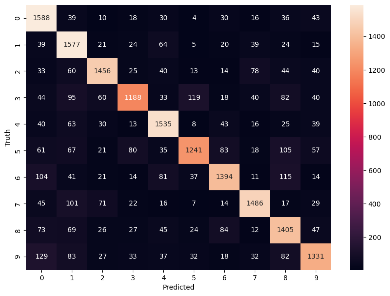

```python
#Heat map
plt.figure(figsize=(10,7))
sns.heatmap(cm,annot=True,fmt='d')
plt.xlabel('Predicted')
plt.ylabel('Truth')
plt.show()
```

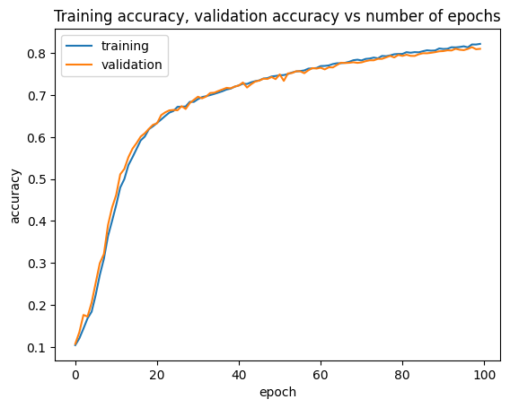

```python
#'Training accuracy, validation accuracy vs number of epochs'
val_accuracy, accuracy  = model.evaluate(x_test, y_test_cat, verbose=False)
plt.plot(NN.history['accuracy'])
plt.plot(NN.history['val_accuracy'])
plt.title('Training accuracy, validation accuracy vs number of epochs')
plt.ylabel('accuracy')
plt.xlabel('epoch')
plt.legend(['training', 'validation'], loc='best')
plt.show()
loss, val_loss  = model.evaluate(x_test, y_test_cat, verbose=False)
```

[figure not shown]

```python
# Training loss, validation loss vs number of epochs
plt.plot(NN.history['val_loss'])
plt.plot(NN.history['loss'])
plt.title('Training loss, validation loss vs number of epochs')
plt.ylabel('loss')
plt.xlabel('epoch')
plt.legend(['training', 'validation'], loc='best')
plt.show()
```

Observations:

1. The best accuracy is provided by single layer sigmoid function, approx 80%.
2. The loss and accuray on traing and validation data is almost samefor the same model.